# Used Cars – Applied ML Project

Siles Lévano Julio César, Niederer Tashi, Roman Alla

01.01.2026

## 1. About the Dataset (Summary)

The dataset provides information on:

**Brand and model** – manufacturer and specific vehicle model

**Model year** – age of the car, influencing depreciation

**Mileage** – an indicator of usage and wear

**Fuel type** – e.g., gasoline, diesel, electric, hybrid

**Engine type** – performance and efficiency characteristics

**Transmission** – automatic or manual

**Exterior/interior colors** – aesthetic properties

**Accident history** – whether the car has previously been damaged

**Clean title** – legal/ownership status

**Price** – listed price of the vehicle

Overall, the dataset offers a structured overview of key features that influence used car valuation. It is well-suited for analytical tasks such as understanding pricing drivers, exploring consumer preferences, and building predictive models for vehicle prices.

We load the original CSV directly from the project data folder using `here()` so paths work regardless of the working directory.

```r
raw_path <- here("data", "raw", "used_cars.csv")
cars_raw <- readr::read_csv(raw_path, show_col_types = FALSE)
```

Basic structure and summary statistics of the raw dataset:

```r
glimpse(cars_raw)
```

```
## Rows: 4,009
## Columns: 12
## $ brand        <chr> "Ford", "Hyundai", "Lexus", "INFINITI", "Audi", "Acura", ~
## $ model        <chr> "Utility Police Interceptor Base", "Palisade SEL", "RX 35~
## $ model_year   <dbl> 2013, 2021, 2022, 2015, 2021, 2016, 2017, 2001, 2021, 202~
## $ milage       <chr> "51,000 mi.", "34,742 mi.", "22,372 mi.", "88,900 mi.", "~
## $ fuel_type    <chr> "E85 Flex Fuel", "Gasoline", "Gasoline", "Hybrid", "Gasol~
## $ engine       <chr> "300.0HP 3.7L V6 Cylinder Engine Flex Fuel Capability", "~
## $ transmission <chr> "6-Speed A/T", "8-Speed Automatic", "Automatic", "7-Speed~
## $ ext_col      <chr> "Black", "Moonlight Cloud", "Blue", "Black", "Glacier Whi~
## $ int_col      <chr> "Black", "Gray", "Black", "Black", "Black", "Ebony.", "Bl~
## $ accident     <chr> "At least 1 accident or damage reported", "At least 1 acc~
## $ clean_title  <chr> "Yes", "Yes", NA, "Yes", NA, NA, "Yes", "Yes", "Yes", "Ye~
## $ price        <chr> "$10,300", "$38,005", "$54,598", "$15,500", "$34,999", "$~
```

## 2. Exploratory Data Analysis

We base the EDA on the engineered dataset (`data/processed/used_cars_features.csv`) that keeps cleaned numeric fields and derived features like age, mileage in thousands, and accident flags.

```r
features_path <- here("data", "processed", "used_cars_features.csv")
cars <- readr::read_delim(features_path, delim = ";", show_col_types = FALSE)
```

### 2.1 Key descriptive values

Key numeric feature summaries

| variable | median | mean | p25 | p75 | sd | min | max |
| --- | --- | --- | --- | --- | --- | --- | --- |
| price_dollar | 28000.00 | 36865.68 | 15500.00 | 46999.00 | 36531.16 | 2000.0 | 649999.00 |
| log_price | 10.24 | 10.19 | 9.65 | 10.76 | 0.82 | 7.6 | 13.38 |
| age | 9.00 | 10.32 | 6.00 | 14.00 | 5.87 | 1.0 | 29.00 |
| milage_k | 63.00 | 72.14 | 30.00 | 103.00 | 53.60 | 0.0 | 405.00 |
| horsepower | 310.00 | 331.51 | 248.00 | 400.00 | 120.32 | 76.0 | 1020.00 |

Accident history distribution

| accident | n | share |
| --- | --- | --- |
| At least 1 accident or damage reported | 871 | 0.28 |
| None reported | 2194 | 0.72 |

Median listing sits around $28k, with the middle 50% between roughly $15.5k and $47k, while the maximum reaches $650k—explaining the heavy right tail. Median age is 9 years (IQR: 6–14), typical mileage is about 63k miles (IQR: 30k–103k), and horsepower clusters around 310 HP (IQR: 248–400). About 28% of cars report an accident or damage, a meaningful factor for pricing.

### 2.2 Price distribution (raw and log)

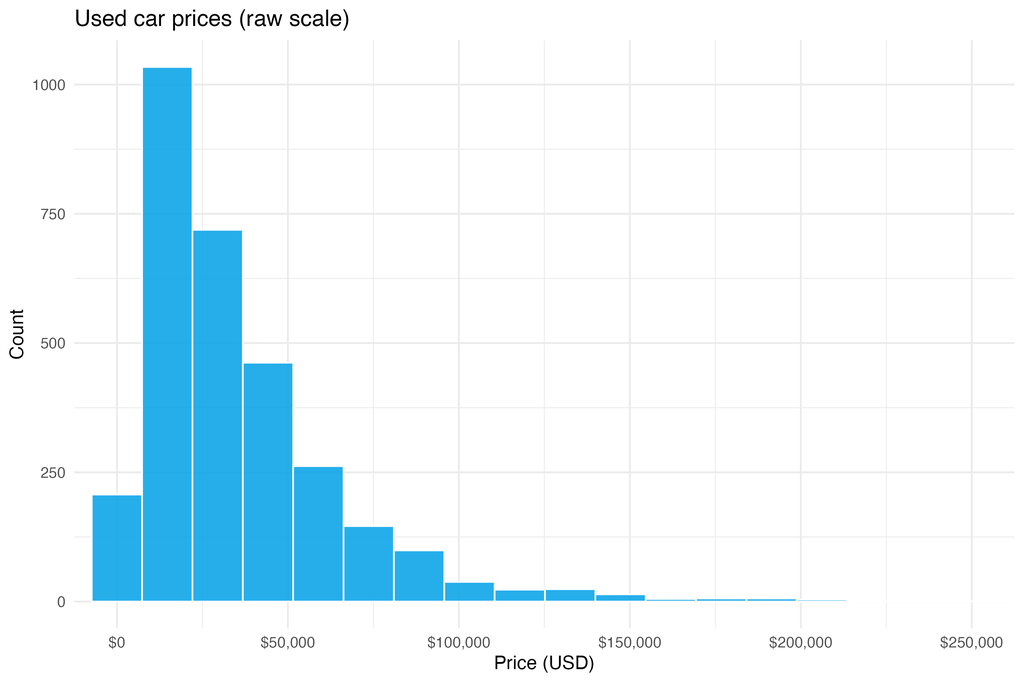

Raw prices are extremely right-skewed, with most listings below $80k but a long tail of luxury and exotic vehicles. Modeling on this scale would be dominated by a few high-price outliers.

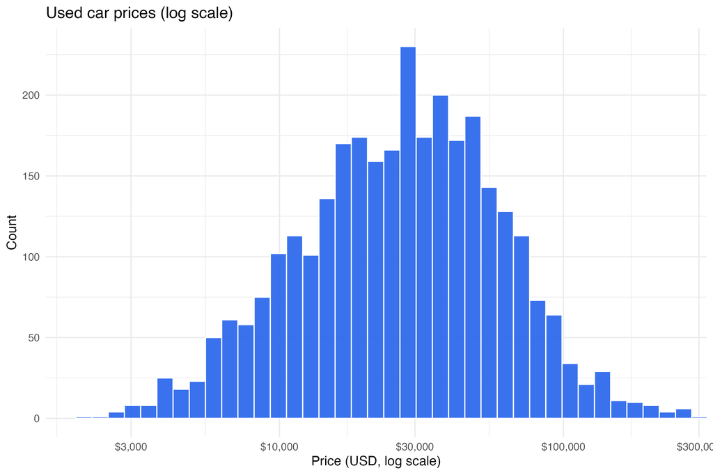

Log transformation produces a more bell-shaped distribution and stabilizes variance, making linear-style models and visual comparisons more reliable.

### 2.3 Depreciation by age and fuel type

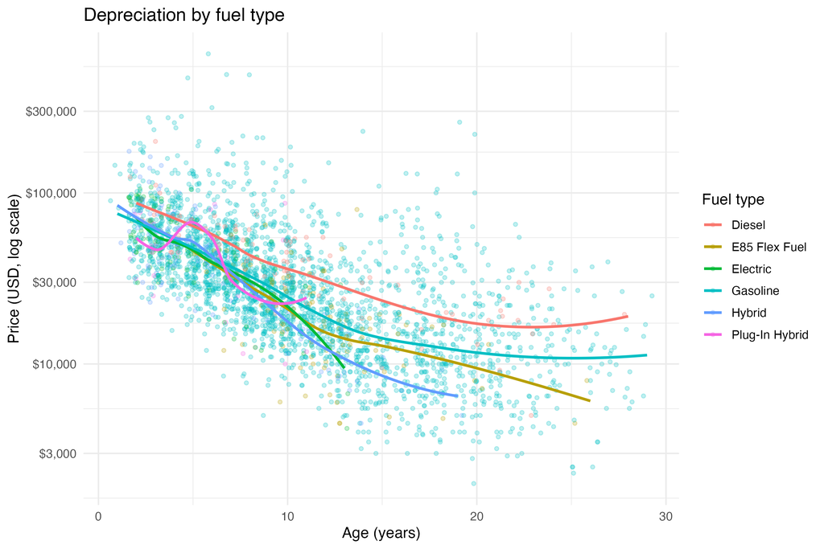

Prices decline with age across fuels. Electric listings start high but show the sharpest early drop; diesel holds comparatively high prices across ages (though the diesel sample is small), and gasoline sits lower overall.

### 2.4 Price spread across top brands

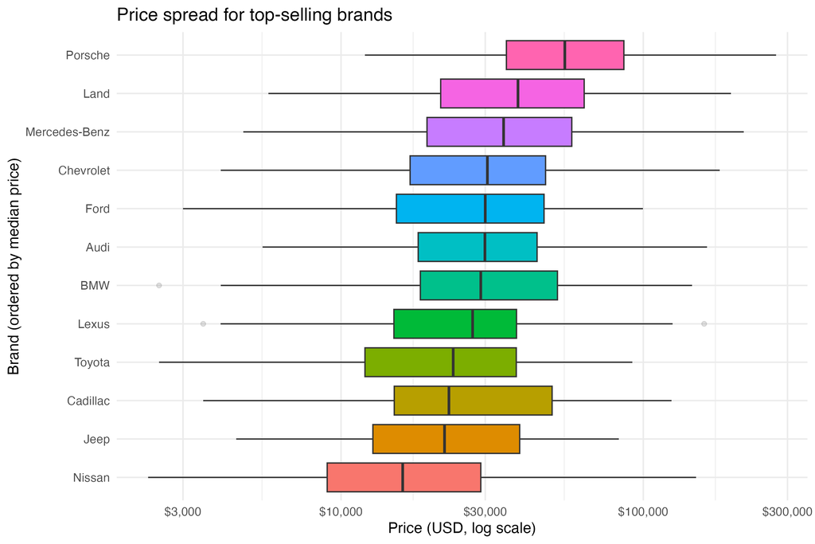

### 2.5 Mileage impact by transmission

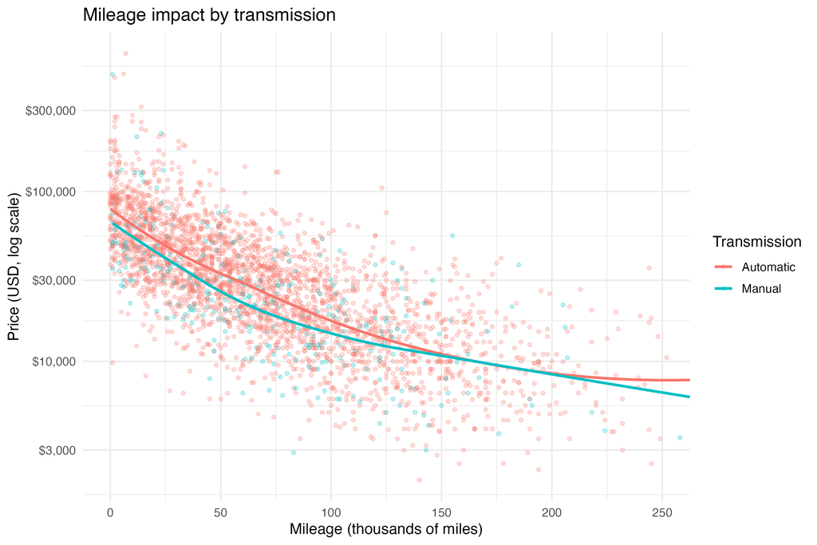

Higher mileage correlates with lower prices. We use a loess smoother (not a straight trendline) and cap the x-axis at 250k miles to reduce the influence of extreme outliers; automatics show a steady decline, and the smaller manual subset is noisier but similar in direction.

### 2.6 Horsepower premium

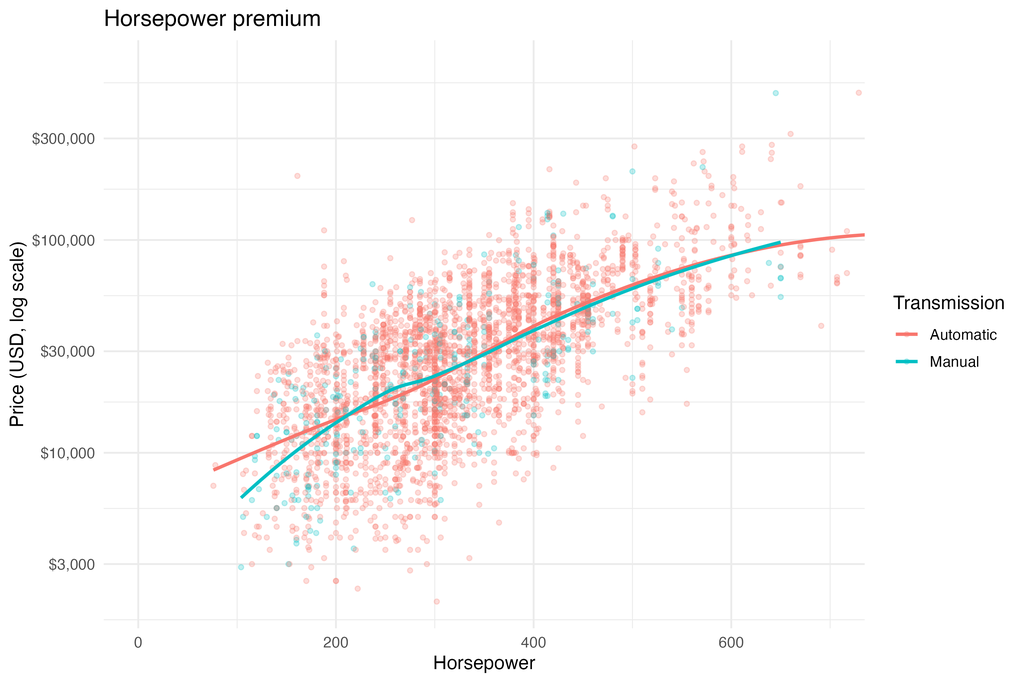

Price rises with horsepower, especially from ~250 HP upward; we cap horsepower at 700 to avoid a handful of ultra-high-HP outliers from distorting the loess smoother, so the trend reflects the bulk of the market rather than extreme sports models.

### 2.7 Accident history effect

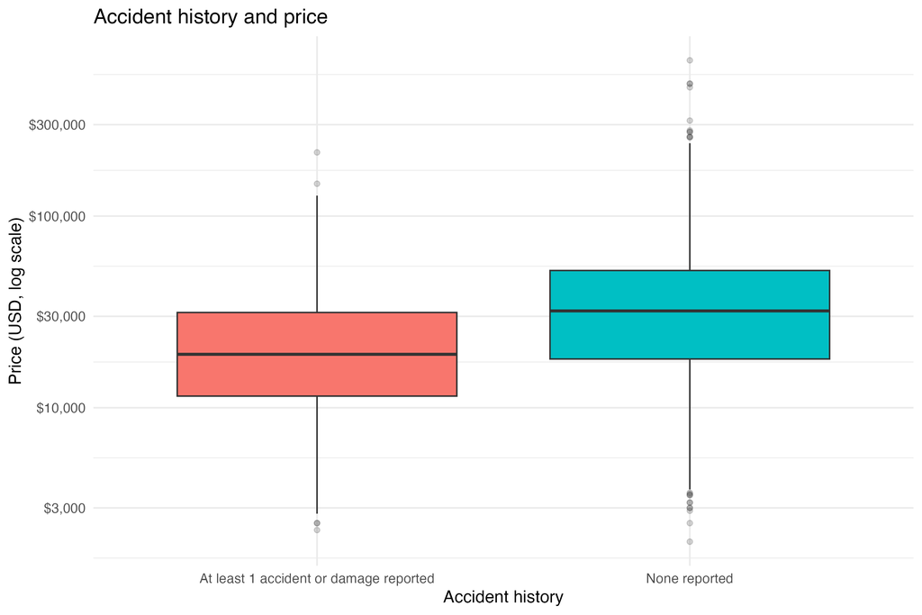

Cars with reported accidents trade at a clear discount relative to clean histories, even after log-scaling prices, confirming accident history as an important predictor.

## 3. Linear regression model

The goal is not primarily to build the most accurate predictor, but to understand which factors drive used-car prices and in which direction.

We model the natural logarithm of the price instead of the raw price because:

- prices are strictly positive and strongly right–skewed,
- taking the log makes the distribution more symmetric,
- the linear model assumptions (linear relationship, constant variance of the residuals) are usually better satisfied on the log scale,
- coefficients can be interpreted approximately as *percentage* effects.

### 3.1. Model specification

We use the feature dataset created in the previous step (`data/processed/used_cars_features.csv`) and fit the following multiple linear regression model on the log-price:

`log_price ~ age + milage_k + accident_bin + brand + fuel_type + transmission + ext_col + int_col`

We intentionally fit an additive baseline linear model without interaction terms. From the current EDA we mainly observe strong main effects (age, mileage, accident history, brand), but no clear and stable “it depends on” patterns (i.e., slope differences across groups) that would justify adding interactions. Including interactions with many categorical predictors would also greatly increase model complexity and reduce interpretability.

Here

- `log_price` is the natural logarithm of the car price in dollars (the target variable / response).
- `age` is the car age in years.
- `milage_k` is the mileage in thousands of miles.
- `accident_bin` is a binary variable  
  (0 = no accident reported, 1 = at least one accident or damage reported).
- `brand`, `fuel_type`, `transmission`, `ext_col` and `int_col` are categorical predictors and are represented in the model by dummy variables with one reference category each.
- The error term (residual) captures the remaining variation not explained by the predictors.

The coefficients of this model measure how much the expected log-price changes when we increase a numeric predictor by one unit (or switch a dummy variable from 0 to 1), while *keeping all other variables fixed*.

### 3.2 Estimation and overall performance

We implement and fit the model by sourcing the script `src/04_model_linear.R`, which

1. loads the feature data (`used_cars_features.csv`),
2. selects the variables listed above and removes rows with missing values,
3. fits the linear model with `stats::lm(...)`, and
4. computes the root mean squared error (RMSE) and $R^2$ on the log-price scale and adds predictions back to the data.

```r
# Fit the baseline linear regression model and prepare lm_linear_data
source(here::here("src", "04_model_linear.R"))

# Show metrics table (RMSE/R² train + test)
knitr::kable(lm_metrics, digits = 3, caption = "Linear regression metrics (target: log_price)")
```

Linear regression metrics (target: log_price)

| model | target | rmse_train | rmse_test | mae_train | mae_test | r2_train | r2_test |
| --- | --- | --- | --- | --- | --- | --- | --- |
| Linear regression | log_price | 0.406 | 0.411 | 0.317 | 0.306 | 0.756 | 0.733 |

```r
# Show a compact summary of the model
broom::tidy(lm_linear) |>
  dplyr::slice(1:10)  # show only first 10 coefficients
```

```
## # A tibble: 10 x 5
##    term          estimate std.error statistic   p.value
##    <chr>            <dbl>     <dbl>     <dbl>     <dbl>
##  1 (Intercept)   11.4      0.129       87.8   0
##  2 age           -0.0572   0.00213    -26.8   2.01e-138
##  3 milage_k      -0.00597  0.000223   -26.8   1.79e-138
##  4 accident_bin  -0.0872   0.0198      -4.40  1.12e-  5
##  5 brandAlfa      0.0348   0.174        0.200 8.41e-  1
##  6 brandAudi      0.252    0.0847       2.98  2.95e-  3
##  7 brandBMW       0.322    0.0804       4.01  6.38e-  5
##  8 brandBentley   1.31     0.126       10.4   9.21e- 25
##  9 brandBuick    -0.0200   0.152       -0.132 8.95e-  1
## 10 brandCadillac  0.304    0.0912       3.33  8.72e-  4
```

### 3.3 Interpretation of selected coefficients

Because the model is fitted on the log(price) scale, each coefficient can be read approximately as a **percentage change in price** when we increase that variable by one unit (or switch a dummy variable from 0 to 1), while keeping all other variables fixed. Roughly, a coefficient of −0.06 means “about −6 %”, a coefficient of +0.20 means “about +22 %”, and so on.

Overall, the signs and magnitudes of the coefficients are plausible: older and higher-mileage cars and cars with accidents are cheaper, while premium brands and certain configurations (e.g. BMW, Ferrari) command much higher prices. With an $R^2$ of about 0.75 on the log-price scale, the model explains a large share of the variation in used car prices, even though there is still substantial unexplained variability.

### 3.4. Relationship between age and log-price

To visualise the effect of age in the linear model, we plot log-price against age and add a fitted linear trend line.

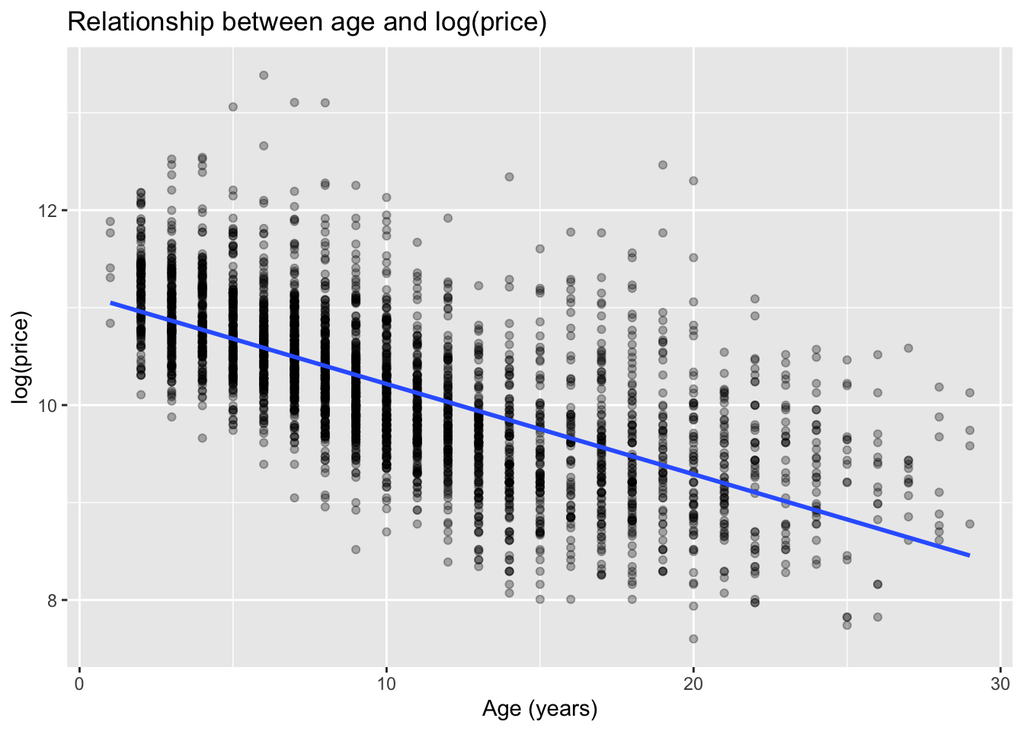

The plot shows the expected negative relationship: older cars tend to have a lower log-price. In our model, the age coefficient is about −0.058, which means that, holding all other variables constant, one additional year of age reduces the expected price by roughly 6 % (because exp(−0.058) ≈ 0.94).

### 3.5. Residual diagnostics

To check whether the linear model assumptions are roughly satisfied, we plot the residuals against the fitted (predicted) log-prices. Ideally, the points are scattered randomly around zero without a clear pattern.

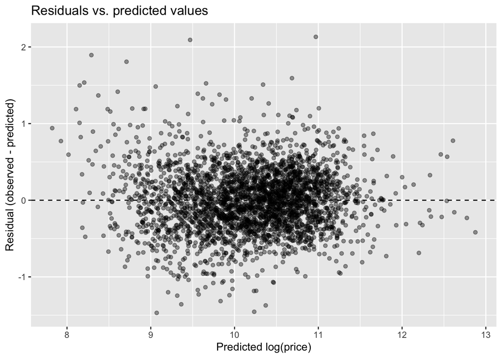

### 3.6 Conclusions (linear regression)

Overall, the linear regression on log(price) provides a simple and interpretable summary of the main price drivers in this dataset. Age and mileage have the expected negative impact on prices, while an accident history leads to a price discount of roughly 8 %. Premium brands such as BMW and especially Ferrari command large price premia, even after controlling for age, mileage and fuel type. The model explains about 75 % of the variance in log-prices, which is quite high for real-world data, but the residual plot also shows that there is still substantial unexplained variability. For a client, this model could already be used as a rough pricing guideline, but more advanced models (e.g. with interactions or nonlinear effects) might capture the remaining structure in the data even better.

## 4. Generalized Linear Model — Binomial (Logistic Regression)

A binomial Generalized Linear Model (GLM) is appropriate when the **response variable is binary**.  
Here, the response variable is:

- `accident_bin`
  - `1` = car has had at least one reported accident
  - `0` = no reported accident

The model estimates the **probability that a used car has an accident history** based on vehicle characteristics.

### 4.1 Model specification

We model accident history using a **logistic regression** with a logit link:

$$\log\left(\frac{P(\text{accident}=1)}{1 - P(\text{accident}=1)}\right)
= \beta_0 + \beta_1 X_1 + \dots + \beta_p X_p$$

Model formula:

`accident_bin ~ brand + age + milage_k + fuel_type + transmission + price_dollar + horsepower + cylinders`

- **Response**: `accident_bin` (binary)
- **Predictors**:
  - Continuous: age, mileage (1,000 miles), price, horsepower, cylinders
  - Categorical: brand, fuel type, transmission
- **Link function**: logit

### 4.2 Model fitting and summary

```r
# Source the script that fits the binomial GLM
source(here::here("src", "05_model_glm_binomial.R"))

# Show a full summary of the model
summary(glm.car)
```

```
##
## Call:
## glm(formula = accident_bin ~ brand + age + milage_k + fuel_type +
##     transmission + price_dollar + horsepower + cylinders, family = "binomial",
##     data = data)
##
## Coefficients:
##                           Estimate Std. Error z value Pr(>|z|)
## (Intercept)             -7.565e-01  4.880e-01  -1.550   0.1211
## brandAlfa               -1.102e+00  1.113e+00  -0.990   0.3221
## brandAudi                2.338e-01  3.826e-01   0.611   0.5412
## brandBMW                -1.410e-01  3.655e-01  -0.386   0.6997
## brandBentley             7.038e-02  7.604e-01   0.093   0.9263
## brandBuick               3.798e-01  6.019e-01   0.631   0.5280
## brandCadillac            4.799e-02  4.195e-01   0.114   0.9089
## brandChevrolet          -2.149e-01  3.804e-01  -0.565   0.5721
## brandChrysler           -6.488e-02  5.726e-01  -0.113   0.9098
## brandDodge               8.623e-02  4.292e-01   0.201   0.8408
## brandFerrari             1.980e+00  1.275e+00   1.553   0.1205
## brandFord               -8.352e-02  3.679e-01  -0.227   0.8204
## brandGMC                 1.849e-01  4.318e-01   0.428   0.6685
## brandGenesis            -1.373e+00  1.095e+00  -1.254   0.2097
## brandHonda              -2.186e-01  4.732e-01  -0.462   0.6441
## brandHummer              3.534e-01  6.157e-01   0.574   0.5660
## brandHyundai             1.307e-01  4.424e-01   0.295   0.7677
## brandINFINITI           -2.661e-01  4.589e-01  -0.580   0.5621
## brandJaguar             -2.984e-02  5.020e-01  -0.059   0.9526
## brandJeep               -3.128e-01  4.153e-01  -0.753   0.4513
## brandKia                -1.944e-01  4.982e-01  -0.390   0.6964
## brandLamborghini        -1.127e+01  3.235e+02  -0.035   0.9722
## brandLand               -7.250e-01  4.439e-01  -1.633   0.1025
## brandLexus               3.271e-01  3.909e-01   0.837   0.4027
## brandLincoln            -1.301e-01  4.753e-01  -0.274   0.7843
## brandMINI               -1.140e+00  6.409e-01  -1.778   0.0754 .
## brandMaserati           -1.064e+00  7.121e-01  -1.494   0.1352
## brandMazda              -4.210e-02  5.076e-01  -0.083   0.9339
## brandMercedes-Benz       8.343e-02  3.713e-01   0.225   0.8222
## brandMitsubishi          1.051e-01  5.975e-01   0.176   0.8604
## brandNissan              1.616e-01  4.075e-01   0.396   0.6918
## brandPontiac            -3.582e-01  6.867e-01  -0.522   0.6019
```

[output cut: 14 more lines]

```
## fuel_typePlug-In Hybrid  4.227e-01  4.819e-01   0.877   0.3803
## transmissionManual      -2.091e-01  1.606e-01  -1.302   0.1929
## price_dollar            -2.169e-05  3.845e-06  -5.642 1.68e-08 ***
## horsepower               1.829e-03  8.796e-04   2.079   0.0376 *
## cylinders               -3.470e-02  5.214e-02  -0.665   0.5058
## ---
## Signif. codes:  0 '***' 0.001 '**' 0.01 '*' 0.05 '.' 0.1 ' ' 1
##
## (Dispersion parameter for binomial family taken to be 1)
##
##     Null deviance: 3658.7  on 3064  degrees of freedom
## Residual deviance: 3306.0  on 3014  degrees of freedom
## AIC: 3408
##
## Number of Fisher Scoring iterations: 14
```

### 4.3 Key Odds Ratios and Interpretation

We scale and exponentiate the coefficients of the binomial GLM to obtain **odds ratios**, which show how the odds of a car having an accident history change with each predictor.

To improve interpretability, continuous predictors are rescaled before computing odds ratios. This rescaling does not affect statistical significance or model fit, only the unit of interpretation.

The data were scaled as follows:

- `milage_k` was multiplied by 10.
- `price_dollar` was multiplied by 1,000.
- `horsepower` was multiplied by 50.

GLM Binomial: Key Odds Ratios and Percent Change (scaled)

| term | odds_ratio | pct_change | p.value | signif |
| --- | --- | --- | --- | --- |
| milage_k | 1.072 | 7.245 | 0.000 | *** |
| fuel_typeElectric | 0.276 | -72.374 | 0.049 | * |
| price_dollar | 0.979 | -2.146 | 0.000 | *** |
| horsepower | 1.096 | 9.575 | 0.038 | * |

**Interpretation of key predictors:**

- **Mileage (`milage_k`)**: Odds ratio > 1 → Higher mileage slightly increases the odds of a reported accident. Specifically, an additional 10,000 miles increases the odds by ~7%, reflecting increased usage and exposure.
- **Price (`price_dollar`)**: Odds ratio < 1 → Higher-priced vehicles are less likely to have an accident. Each additional $1,000 reduces the odds by ~2%, suggesting that more expensive cars are generally newer or better maintained.
- **Horsepower (`horsepower`)**: Odds ratio > 1 → More powerful cars slightly increase accident odds. For example, a 50 HP increase raises the odds by ~9.5%, possibly due to more spirited driving.
- **Fuel type – Electric (`fuel_typeElectric`)**: Odds ratio << 1 → Electric cars have substantially lower odds (≈ 72 % lower) of reported accidents compared to the reference fuel type. This effect should be interpreted cautiously, as electric vehicles in this dataset are generally newer and may benefit from modern safety technologies.

These odds ratios allow for an intuitive interpretation of how each variable affects accident probability, holding all other variables constant. Most other predictors (brand, transmission, cylinders, age) were not statistically significant in this model.

### 4.4 Conclusions (Binomial GLM)

The binomial GLM indicates that accident probability is primarily driven by vehicle usage and value. Higher mileage and higher horsepower are associated with increased accident odds, while higher-priced cars are less likely to have a reported accident history. This is consistent with the intuition that cheaper cars tend to be older, more heavily used, and exposed to greater wear and risk. Electric vehicles exhibit substantially lower accident odds in the model. However, this result is likely influenced by sample composition: electric cars in the dataset are generally newer and therefore have had less exposure time to accidents. The observed fuel-type effect may therefore partially reflect vehicle age rather than an intrinsic safety advantage. Overall, the GLM provides a transparent and interpretable baseline model for accident risk. Its linear structure, however, limits its ability to capture nonlinear exposure effects, motivating the use of a Generalised Additive Model in the next section.

## 5. Generalized Linear Model — Poisson

A Poisson GLM is typically used when the **response variable is a count** (non-negative integers). Because this dataset does not contain a natural event count, we use a pragmatic proxy: **mileage in thousands** (`milage_k`), converted to an integer “count-like” variable (`milage_k_count`).  
This section mainly demonstrates the **Poisson GLM workflow and interpretation**.

### 5.1 Model specification

We model the expected mileage count (in thousands) using a Poisson GLM with a log link:

`milage_k_count ~ age + accident_bin + brand + fuel_type + transmission + ext_col + int_col`

In a Poisson GLM with log link:

- Response: `milage_k_count` (non-negative integer proxy)
- Predictors: age, accident history, and categorical vehicle characteristics
- Link: `log( E[milage_k_count] ) = linear predictor`

So coefficients are interpreted **multiplicatively**:  
`exp(beta)` is the factor change in the expected count for a one-unit increase (or dummy switch), holding other variables fixed.

### 5.2 Estimation and overall performance

We fit the Poisson GLM by sourcing `src/06_model_glm_poisson.R`, which: 1) loads the feature data,  
2) creates the count-like response `milage_k_count`,  
3) fits a Poisson GLM with log link,  
4) evaluates the model using train/test RMSE (on the count scale) and additional diagnostics (AIC, deviance-based pseudo-R², and Pearson dispersion for overdispersion), and  
5) adds predictions/residuals back to the data.

```r
source(here::here("src", "06_model_glm_poisson.R"))

knitr::kable(poisson_metrics, digits = 3, caption = "Poisson GLM metrics (target: milage_k_count)")
```

Poisson GLM metrics (target: milage_k_count)

| model | target | rmse_train | rmse_test | AIC | pseudo_R2_deviance | dispersion_pearson |
| --- | --- | --- | --- | --- | --- | --- |
| Poisson GLM | milage_k_count | 39.462 | 41.11 | 63503.28 | 0.493 | 20.505 |

```
##        AIC pseudo_R2_deviance dispersion_pearson
## 1 63503.28          0.4928358           20.50528
```

If the **dispersion** is clearly above 1, the Poisson variance assumption (mean ≈ variance) may be violated (overdispersion). In a real use case you’d consider a quasi-Poisson or negative binomial model. We keep Poisson here for comparability and interpretation practice.

### 5.3 Interpretation of selected coefficients

In a Poisson GLM with log link, coefficients are interpreted via rate ratios. A rate ratio exp(β) > 1 means a higher expected mileage count, exp(β) < 1 means a lower expected mileage count, holding other variables constant.

Poisson GLM: selected effects on expected milage_k_count

| term | estimate | rate_ratio | pct_change | p.value |
| --- | --- | --- | --- | --- |
| age | 0.0684505 | 1.071 | 7.1 | 0.00e+00 |
| accident_bin | 0.2065339 | 1.229 | 22.9 | 0.00e+00 |
| fuel_typeElectric | -1.0093889 | 0.364 | -63.6 | 2.88e-156 |
| transmissionManual | -0.3109655 | 0.733 | -26.7 | 1.23e-272 |

**Interpretation of selected coefficients (Poisson GLM)**  
In this Poisson GLM, the response variable is `milage_k_count` (mileage in thousands of miles, rounded to an integer). With a log link, coefficients are interpreted as **multiplicative effects** on the expected mileage count: `exp(β)` is a “rate ratio”. Values above 1 indicate higher expected mileage, values below 1 indicate lower expected mileage, holding all other variables constant.

### 5.4 Residual diagnostics

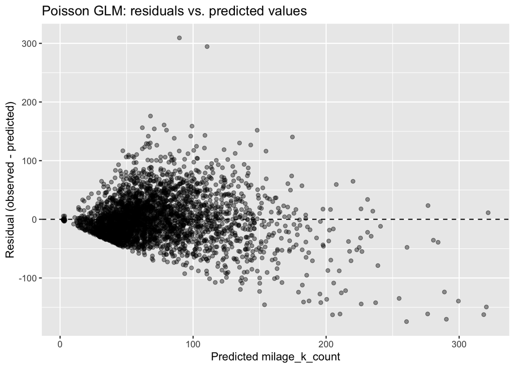

### 5.5 Conclusions (Poisson GLM)

The Poisson GLM demonstrates how to model a count-like response with a log link and interpret effects as multiplicative changes via `exp(beta)`. While `milage_k_count` is not a true event count, this workflow is useful to practice GLM estimation, interpretation, and basic diagnostics. In a real client setting with genuine count outcomes, overdispersion should be checked carefully and a quasi-Poisson or negative binomial model may be more appropriate.

## 6. Generalised Additive Model (GAM)

To relax the linearity assumption of the binomial GLM, we fit a **Generalised Additive Model (GAM)** to predict whether a car has had at least one reported accident (accident_bin). The GAM allows for **non-linear relationships** between key continuous predictors and accident probability, while retaining interpretable parametric effects for categorical variables.

### 6.1 Model specification

We model accident history using a GAM with a binomial family and logit link:

`accident_bin ~ brand + fuel_type + transmission + cylinders + s(milage_k) + s(price_dollar) + s(horsepower) + s(age)`

Where: - `accident_bin` is a binary response (0 = no reported accident, 1 = at least one reported accident). - `brand`, `fuel_type`, and `transmission` are categorical predictors. - `cylinders` enters the model linearly. - `s(milage_k)`, `s(price_dollar)`, `s(horsepower)`, and `s(age)` are smooth spline functions capturing potential nonlinear effects. - The model is estimated using penalised likelihood with REML.

### 6.2 Model fitting and summary

Smoothness is selected automatically via REML, reducing the risk of overfitting despite flexible spline terms.

```r
source(here::here("src", "07_model_gam.R"))

# Show a full summary of the model
summary(gam.car)
```

```
##
## Family: binomial
## Link function: logit
##
## Formula:
## accident_bin ~ brand + fuel_type + transmission + cylinders +
##     s(milage_k) + s(price_dollar) + s(horsepower) + s(age)
##
## Parametric coefficients:
##                           Estimate Std. Error z value Pr(>|z|)
## (Intercept)             -8.419e-01  5.449e-01  -1.545   0.1223
## brandAlfa               -1.006e+00  1.123e+00  -0.895   0.3705
## brandAudi                1.611e-01  3.881e-01   0.415   0.6780
## brandBMW                -1.905e-01  3.710e-01  -0.513   0.6077
## brandBentley            -3.536e-01  7.696e-01  -0.459   0.6459
## brandBuick               3.009e-01  6.049e-01   0.497   0.6189
## brandCadillac            7.582e-03  4.240e-01   0.018   0.9857
## brandChevrolet          -1.726e-01  3.858e-01  -0.447   0.6546
## brandChrysler           -8.121e-02  5.774e-01  -0.141   0.8881
## brandDodge               1.182e-01  4.339e-01   0.272   0.7853
## brandFerrari             9.463e-01  1.290e+00   0.733   0.4634
## brandFord               -6.184e-02  3.736e-01  -0.166   0.8685
## brandGMC                 2.126e-01  4.378e-01   0.486   0.6272
## brandGenesis            -1.085e+00  1.114e+00  -0.974   0.3303
## brandHonda              -2.836e-01  4.795e-01  -0.591   0.5543
## brandHummer              4.498e-01  6.215e-01   0.724   0.4692
## brandHyundai             9.541e-02  4.502e-01   0.212   0.8322
## brandINFINITI           -2.988e-01  4.638e-01  -0.644   0.5195
## brandJaguar             -7.691e-02  5.063e-01  -0.152   0.8793
## brandJeep               -3.293e-01  4.214e-01  -0.781   0.4346
## brandKia                -1.080e-01  5.125e-01  -0.211   0.8331
## brandLamborghini        -3.667e+01  1.861e+07   0.000   1.0000
## brandLand               -7.975e-01  4.482e-01  -1.779   0.0752 .
## brandLexus               2.860e-01  3.964e-01   0.722   0.4706
## brandLincoln            -1.300e-01  4.806e-01  -0.270   0.7868
## brandMINI               -1.305e+00  6.480e-01  -2.014   0.0440 *
## brandMaserati           -1.126e+00  7.196e-01  -1.565   0.1177
## brandMazda              -1.007e-01  5.153e-01  -0.195   0.8451
## brandMercedes-Benz      -2.690e-02  3.773e-01  -0.071   0.9432
## brandMitsubishi          4.319e-02  6.045e-01   0.071   0.9430
```

[output cut: 16 more lines]

```
## cylinders                7.551e-03  5.476e-02   0.138   0.8903
## ---
## Signif. codes:  0 '***' 0.001 '**' 0.01 '*' 0.05 '.' 0.1 ' ' 1
##
## Approximate significance of smooth terms:
##                   edf Ref.df Chi.sq p-value
## s(milage_k)     5.696  6.819 45.201 < 2e-16 ***
## s(price_dollar) 2.266  2.989 14.054 0.00284 **
## s(horsepower)   2.212  2.862  4.814 0.21619
## s(age)          3.077  3.898  8.022 0.07772 .
## ---
## Signif. codes:  0 '***' 0.001 '**' 0.01 '*' 0.05 '.' 0.1 ' ' 1
##
## R-sq.(adj) =  0.102   Deviance explained = 11.1%
## -REML = 1623.1  Scale est. = 1         n = 3065
```

The summary output reports estimated degrees of freedom (EDF) and approximate significance tests for each smooth term.

### 6.3 Interpretation of smooth effects

The GAM summary reports estimated degrees of freedom (EDF) and significance tests for each smooth term, indicating whether nonlinear effects are present.

- **Mileage (`s(milage_k)`)**  
  Mileage shows a **highly significant and strongly nonlinear effect** on accident probability (EDF ≈ 5.7, p < 2e−16). The relatively large EDF indicates a complex relationship: accident risk does not increase at a constant rate with mileage. Instead, the effect varies across usage levels, reflecting changing exposure and driving patterns over a vehicle’s lifetime.
- **Price (`s(price_dollar)`)**  
  Price has a **statistically significant smooth effect** (EDF ≈ 2.3, p = 0.0028). While the effect is nonlinear, its lower EDF suggests a shape close to linear. Higher-priced vehicles tend to have a lower probability of reported accidents, consistent with newer vehicles, better maintenance, and improved safety features.
- **Horsepower (`s(horsepower)`)**  
  The smooth effect of horsepower is **not statistically significant** (p = 0.216). Although horsepower is modelled flexibly, the data provide no strong evidence that engine power independently affects accident probability once mileage, price, and other characteristics are controlled for.
- **Age (`s(age)`)**  
  The smooth effect of age is **marginally insignificant** (p = 0.078). This suggests that age alone does not strongly predict accident probability after accounting for mileage and vehicle characteristics. Much of the age-related risk appears to be captured indirectly through mileage.

Overall, mileage and price emerge as the most important nonlinear predictors of accident history in the GAM.

### 6.4 Interpretation of parametric effects

The parametric terms (brand, fuel type, transmission, and cylinders) are interpreted as in a standard logistic regression, holding all smooth effects constant.

- **Brand effects**  
  Most brand coefficients are not statistically significant, indicating limited brand-specific differences in accident probability after controlling for mileage, price, and other variables. One exception is **MINI**, which shows a significantly lower accident probability compared to the reference brand (p = 0.044).
- **Fuel type**  
  Fuel type coefficients are not statistically significant. Electric vehicles show a negative coefficient, suggesting lower accident odds, but this effect is not significant once nonlinear mileage and price effects are accounted for.
- **Transmission**  
  Manual transmission does not have a statistically significant effect on accident probability in this model.
- **Cylinders**  
  The number of cylinders enters linearly and is not statistically significant, suggesting little direct impact on accident risk.

Overall, categorical vehicle characteristics play a secondary role compared to usage-related variables such as mileage and price.

### 6.5 Conclusions (GAM)

The Generalised Additive Model identifies mileage as the dominant predictor of accident risk, showing a highly significant and nonlinear relationship with the probability of reported accidents. Vehicle price also matters: lower-priced cars are more likely to have had accidents. Other continuous predictors, including horsepower and age, show no strong independent effects once the nonlinear patterns of mileage and price are accounted for. Most categorical variables brand, fuel type, transmission, and cylinders are not statistically significant, suggesting that accident risk is driven primarily by usage intensity and vehicle value, rather than brand identity. Compared to the linear binomial GLM, the GAM captures nonlinear effects and provides a more nuanced and interpretable view of accident risk, although overall predictive power remains limited due to the inherent randomness of accidents.

## 7. SVM model (regression)

We fit Support Vector Machine (SVM) regression models to predict `log_price`. We used two libraries: `e1071` and `kernlab` (via `caret::train`). Both models employ a radial kernel to capture non-linear relationships in the data.

### 7.1 Model specification

1. Loads the engineered car data (used_cars_features.csv) and keep the predictors plus `log_price` target.
2. Splits the data `80/20` into train/test (seeded for reproducibility).
3. Defines a helper to compute RMSE/MAE/R² .
4. Fits two radial SVM regressors:
   - `e1071` svm tuned over a small cost/gamma grid with cross validation. 3-fold cross validation inside tune() selects the best combo on the training split.
   - `caret/kernlab` + `svmRadial` tuned over a small C/sigma grid with 3-fold cross validation.
5. Predict on the held-out test set for each model, compute metrics, and save:
- Models (svm_log_price_e1071.rds, svm_log_price_kernlab.rds)
- Test predictions (per model CSVs)
- Combined metrics RMSE, MAE, R² (svm_log_price_metrics.csv)

### 7.2 Cross-validation

`e1071` As you see on the heatmap, some areas have similar green shades, indicating comparable performance across those parameter combinations. However, the lowest RMSE for e1071 was achieved with following parameters: cost=4, gamma=0.05 (CV RMSE=0.2846)

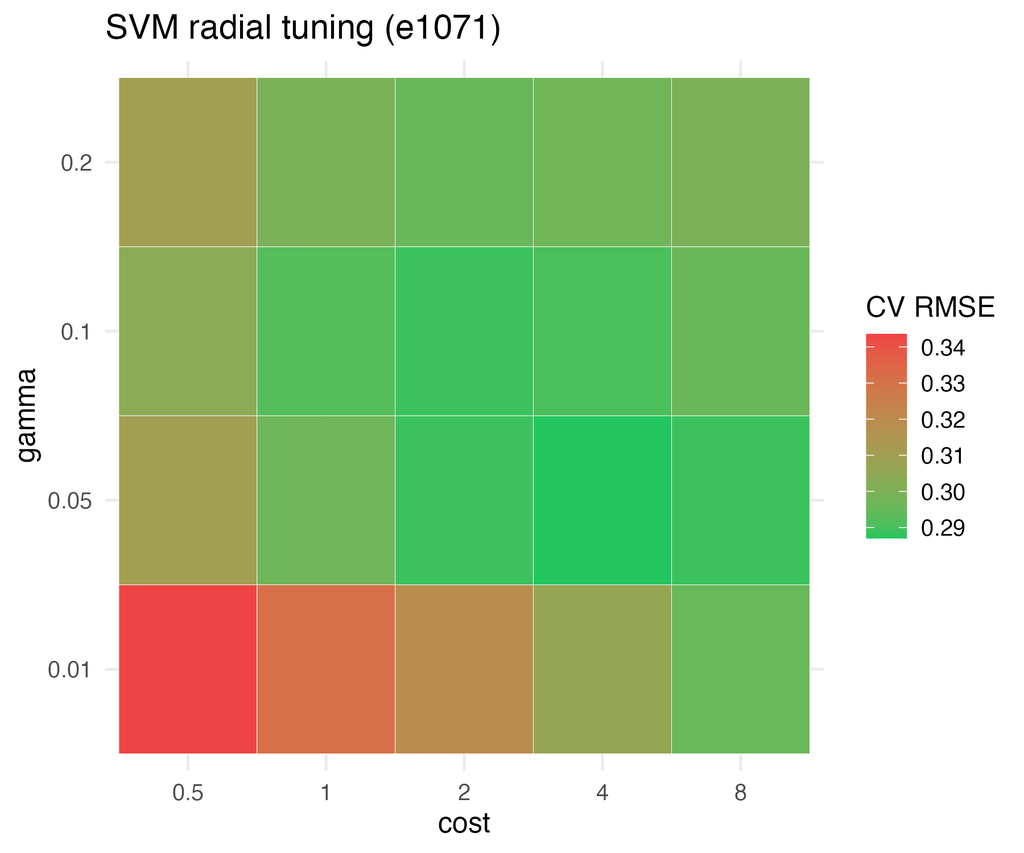

`caret/kernlab` And here you can see best kernlab parameters: C=2, sigma=0.01 (CV RMSE=0.4298)

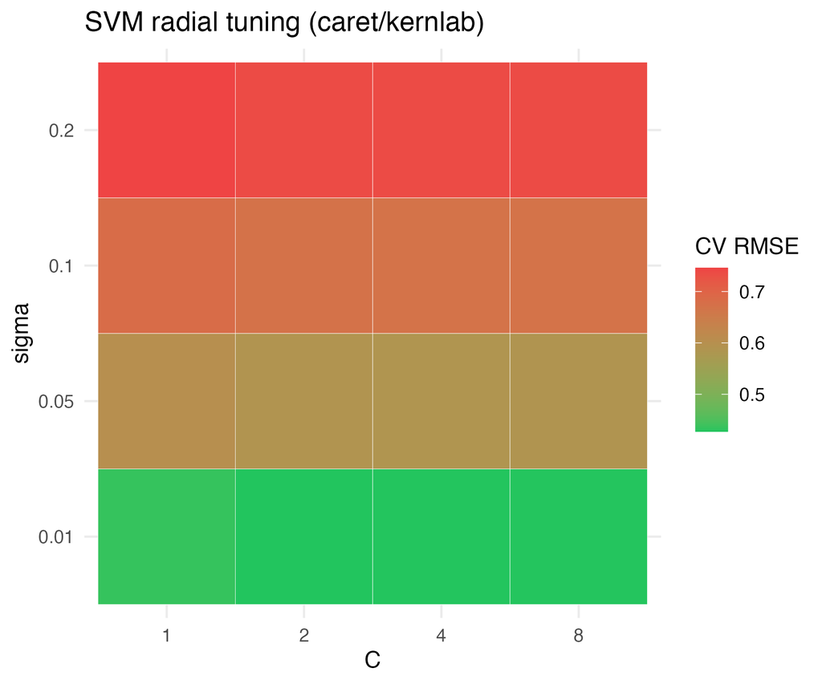

### 7.3 RMSE/MAE/R² on test split

The radial Support Vector Machine from the e1071 package performs best, showing the smallest average prediction error (RMSE ≈ 0.29) and explaining about 87% of the variation in used-car prices, outperforming the alternative SVM model. SVMs do not yield straightforward coefficient interpretations; they learn support vectors and decision functions in a transformed feature space.

Test metrics for SVM variants (target: log_price)

| .estimator | model | rmse | mae | rsq |
| --- | --- | --- | --- | --- |
| standard | e1071_radial | 0.290 | 0.209 | 0.868 |
| standard | kernlab_radial | 0.354 | 0.251 | 0.803 |

### 7.4 Interpretation of results

Both models show strong agreement between predicted and true prices, with points clustering closely around the diagonal and the smooth curve largely overlapping the ideal line, indicating good calibration and limited systematic bias. Slight over-prediction is visible for very low-priced cars and mild under-prediction for the most expensive vehicles, a common pattern in pricing problems. The e1071 radial SVM exhibits marginally tighter clustering and smoother alignment with the diagonal, consistent with its lower RMSE and higher R².

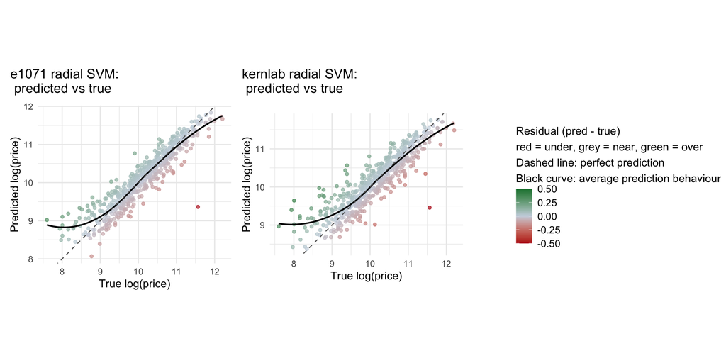

## 8. Neural network model (regression)

We fit two neural networks to predict `log_price`: a caret `nnet` with preprocessing/tuning and a manual `neuralnet` with a shallow hidden layer.

### 8.1 Model specification

- Load the engineered data and keep predictors plus `log_price`.
- Split 80/20 into train/test (seeded).
- caret `nnet`: recipe with dummy variables + zero-variance filter + centering/scaling; 3-fold cross validation over a small size/decay grid; `maxit=300`.
- manual `neuralnet`: one hidden layer (4 units) on scaled/dummified matrix, with optional subsampling for speed.
- Save models, per-model predictions, and combined metrics to `report/models/nn`.

### 8.2 Cross-validation

- caret tuning uses 3-fold cross validation on the training split to choose size/decay; the manual `neuralnet` uses fixed architecture (no CV tuning).
- CV metrics come from training folds; test metrics come from the untouched 20% hold-out.
- Only one heatmap is shown because only the caret model does a grid search; the manual neuralnet keeps a single, simple layout without tuning.

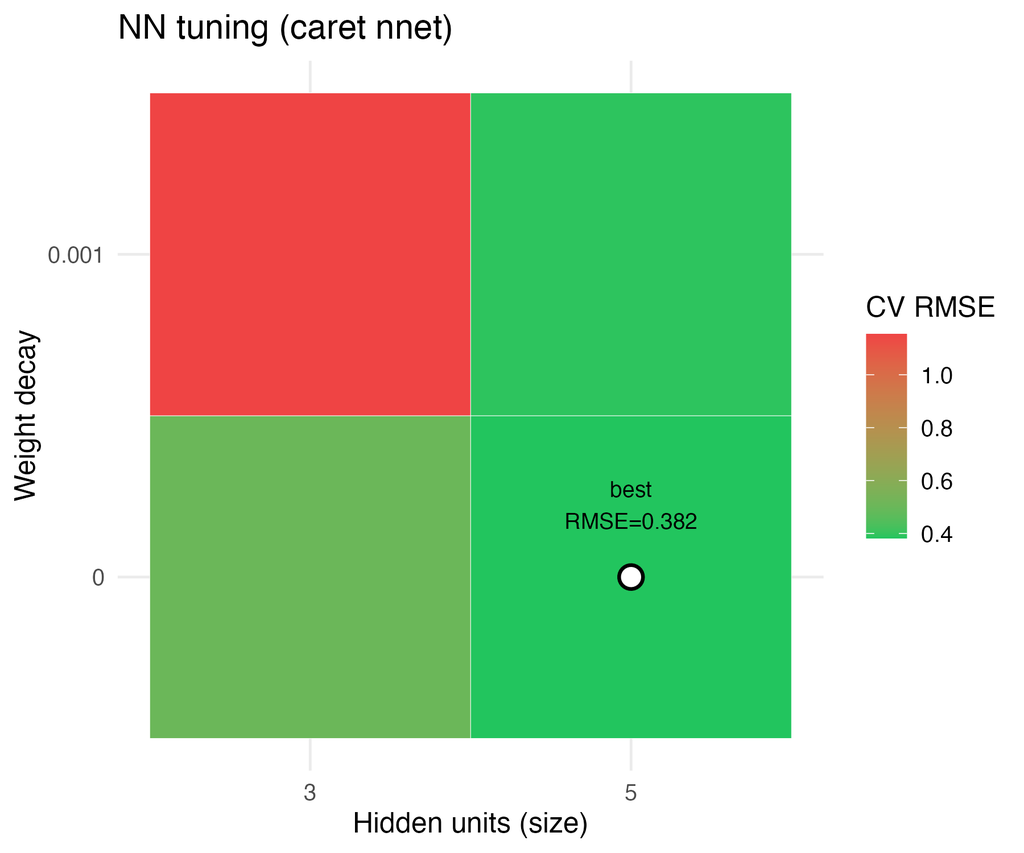

### 8.3 RMSE/MAE/R² on test split

Test metrics for NN variants (target: log_price)

| .estimator | model | rmse | mae | rsq |
| --- | --- | --- | --- | --- |
| standard | caret_nnet | 0.360 | 0.262 | 0.799 |
| standard | neuralnet_manual | 0.443 | 0.301 | 0.695 |

### 8.4 Interpretation of results

Both neural network models capture the strong relationship between observed and predicted log-transformed prices, indicating that the main structure of the data is well learned. Predictions are generally accurate across the central price range, where most observations lie, with limited overall bias.

The caret-based neural network shows more stable and consistent performance across different price levels. In contrast, the manually specified neural network exhibits greater variability in its predictions, particularly for higher-priced vehicles, where underestimation is more pronounced.

Overall, while both neural networks perform well, the caret implementation delivers more reliable predictions across the full price range and is therefore preferred in this analysis.

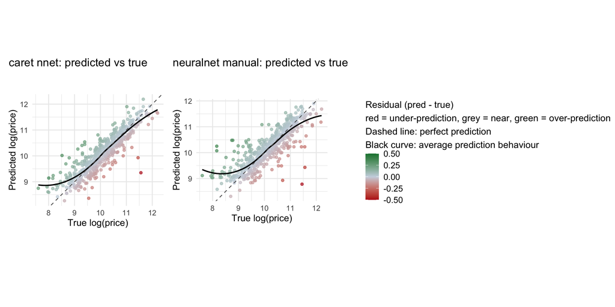

## 9. Model comparison: linear regression vs. SVM

Both models use the same 80/20 train-test split (stored in `data/processed/train_test_split.rds`). The table below compares the linear regression on `log_price` to the best-performing SVM.

### 9.1 Evaluation metrics

Test metrics on shared split (log_price)

| model | rmse | mae | r2 |
| --- | --- | --- | --- |
| Linear regression | 0.411 | 0.306 | 0.733 |
| SVM e1071_radial | 0.290 | 0.209 | 0.868 |

### 9.2 Interpretation

On the shared test set, the radial SVM clearly outperforms the linear regression model, achieving substantially lower prediction errors (RMSE 0.290 vs 0.411, MAE 0.209 vs 0.306) and explaining a larger share of the variation in log-prices (R² 0.868 vs 0.733). While a fair comparison could in principle involve extending the linear regression with interaction terms or non-linear effects, we intentionally retain a simple additive baseline specification. The exploratory analysis reveals strong main effects but no clear or stable interaction patterns, and adding such complexity - particularly with multiple categorical predictors - would substantially reduce interpretability. Although the linear model captures the main price trends and remains valuable for explanation, its linear structure limits predictive accuracy. In contrast, the SVM’s ability to model non-linear relationships leads to more accurate predictions across the full price range. Overall, this comparison highlights the trade-off between interpretability and predictive performance, with the SVM being the preferred model when prediction accuracy is the primary objective.

## 10. Model Comparison – Accident History

*(Binomial GLM vs. Binomial GAM)*

Because `accident_bin` is a binary outcome, we compare only models suitable for classification: the **binomial GLM (logistic regression)** and the **binomial GAM**. Both models were trained on the same feature set and evaluated on the same train/test split.

### 10.1 Evaluation metrics

Predictive performance for accident history models (20% random test set)

| Model | Accuracy | AUC |
| --- | --- | --- |
| Binomial GLM | 0.724 | 0.704 |
| Binomial GAM | 0.728 | 0.707 |

### 10.2 Interpretation

The binomial GAM slightly outperforms the GLM (Accuracy 0.728 vs. 0.724; AUC 0.707 vs. 0.704) by capturing nonlinear effects in the data. The GLM provides a simple, interpretable baseline, while the GAM offers a more flexible model that better fits the patterns in accident history.

## 11. Summary and conclusions

This project applies the full machine learning workflow from data preparation and exploratory analysis to model estimation, evaluation, and interpretation. The results demonstrate that data cleaning and feature engineering are central to model performance and often more influential than the choice of algorithm. In particular, transforming the price variable and carefully processing categorical predictors were essential for stable estimation.

Exploratory analysis revealed strong skewness in used car prices and pronounced nonlinear relationships, especially for mileage and price. These findings motivated the use of flexible modelling approaches beyond simple linear specifications.

All models were trained on the same data and compared using a common held out test split, ensuring a fair evaluation. Linear regression provided transparent insight into the main pricing drivers, whereas more flexible methods, most notably the radial Support Vector Machine, achieved substantially higher predictive accuracy by capturing complex nonlinear patterns.

Overall, the analysis shows that effective applied machine learning relies not only on sophisticated algorithms but fundamentally on high quality data preparation, rigorous evaluation design, and clear communication aligned with the analytical objective.

## 12. Use of Generative AI

We used generative AI as a support tool for coding and report writing. For coding, it helped us clarify R/statistical concepts (e.g., GLM assumptions, coefficient interpretation with log link, select() vs. transmute()), debug knitting errors, and draft structured template code for model scripts (train/test split, RMSE calculation, storing metrics). For writing, it supported drafting and refining report text (model descriptions, interpretation of results, and metric explanations) to keep a consistent structure across sections.

It was easy to obtain quick explanations and first drafts. It was harder to ensure suggestions matched our exact project setup (correct variable names, shared train/test split, and what was actually implemented). Some things are unreliable without verification, e.g., assuming code will run unchanged or that generic modelling advice applies directly.

Therefore, we critically checked all AI outputs by running the code locally, validating that metrics were computed on the correct split, confirming interpretations with the correct formulas, and removing any text not supported by our results. Generative AI improved productivity, but correctness and final decisions were ensured by the group through testing and review.